# Module 1: Loading, Saving, Data QC, Scripting, Getting Help

Ted Laderas

July 9, 2015

## Welcome

Welcome to the R-Bootcamp! This is a RMarkdown document. The code that you will need to run is in the blocks that start with “```{r}”. You can run the code in the console by highlighting it and using CTRL+ENTER (Windows/Linux) or CMD+ENTER (Mac).

The nice thing about RMarkdown is that you can use it to compile your code and text into a nice report. If you change any code, it gets re-run every time you knit the RMarkdown report.

You can see an example of a compiled report as a the Module1/module1.html. We’ll install knitr (which is needed to compile RMarkdown) at the end of this module. Then, when you’re done, you can knit your code and have a nice output of everything you’ve done.

### Resources and Help

You can always get a help page for a function using ? or help(). The examples (usually at the bottom of the help file) are the most helpful inunderstanding inputs and outputs to a function.

```r
?read.table
help()
```

R can be run from the command line, or the R interpreter. It’s probably easiest to run it from an IDE such as RStudio when working through these modules.

### Installing R-studio:

http://cran.r-project.org/doc/contrib/Torfs+Brauer-Short-R-Intro.pdf

Much of this bootcamp is derived from An Introduction to R: http://cran.r-project.org/doc/manuals/R-intro.pdf

The following two texts will be more useful further on, but are good reads and references. *[Introductory Statistics Using R](http://www.springer.com/mathematics/probability/book/978-0-387-79053-4)*: The first 53 pages are a helpful reference to those who are getting started. (A PDF can be found if you look around).

*[R-Cookbook](http://www.amazon.com/Cookbook-OReilly-Cookbooks-Paul-Teetor/dp/0596809158)*. This is a recipe-driven approach to learning code. This will be useful once you learn the basics.

## Part 0: Getting started

Let’s find out the current working directory - this is the directory where your work will be saved and where you can directly access files

```r
getwd()
```

```
## [1] "/Users/roshi/Code/r-bootcamp/module1"
```

You can see the current files in the directory by using list.files()

```r
list.files()
```

```
##  [1] "module1-final-problem-solution.R" "module1-final-problem.R"
##  [3] "module1-modified.RData"           "module1-problems-and-answers.R"
##  [5] "module1.html"                     "module1.md"
##  [7] "module1.R"                        "module1.RData"
##  [9] "module1.Rmd"                      "mouseData-boxplot.png"
## [11] "mouseData-histogram.pdf"          "mouseData.txt"
## [13] "mouseData2.csv"                   "Rhistory"
## [15] "testScript.R"
```

### Changing Working Directory

You can also use “change dir” under the “File” menu.

Change the following command to the directory with the module 1 files. Note that even on Windows, we use “/” (forward slash) rather than “" (reverse slash)

```r
##for windows buffs
setwd("c:/")
##for linux/mac os x buffs
setwd("~/Desktop")
```

Set your working directory to the folder that contains the “module1.RData” file.

```r
setwd(".")
```

In terms of best practices and reproducbility, it’s best to not change directories in the middle of a script (as the script can break when it’s run in a different system), so try and keep data files and associated scripts in the same directory.

### Loading a Workspace

You can also load workspaces via “Load Workspace” under the File menu

```r
load("module1.RData")
```

Let’s look at what’s in this workspace

```r
ls()
```

```
## [1] "iris"       "testObject"
```

With the ls() command, you can find files that match a certain pattern

```r
ls(pattern="iris")
```

```
## [1] "iris"
```

Another thing we can do is can find out what class an R object is:

```r
class(iris)
```

```
## [1] "data.frame"
```

We can also remove objects from the workspace:

```r
#look at testObject first
testObject
```

```
## [1] 1 2 3 4
```

```r
#remove testObject
rm(testObject)
```

We can remove everything in the workspace by using this command.

```r
#obviously don't run this right now
#rm(list=ls())
```

**QUESTION 0-1**: How does this work? Hint: read the help file for rm()

```r
?rm
```

## Saving a Workspace

If you’re in the middle of something, but need to quit, you can use save.image() to save your progress in the workspace. Then you can use load() to load up your file.

```r
save.image("module1-modified.RData")
load("module1-modified.RData")
```

## Part 1: Loading Data

Let’s load in a data file.

First off, take a look at mouseData.txt in a text editor. What do you notice? How are the fields separated?

Let’s load this data file. We’ll need to specify the separator. Note the “<-” operator assigns the output to an object

```r
mouseData <- read.table(file = "mouseData.txt", header=TRUE, sep="\t")
```

For the most part, the “=” operator is equivalent to “<-”. However, I tend to use “<-” because it I do not confuse assigning a value to a variable with the comparison operator “==”.

```r
mouseData = read.table(file = "mouseData.txt", header=TRUE, sep="\t")
```

One difference between “<-” and “=” is that there is an equivalent operator “->” if you wanted to do left to right assignment.

The following two assignments are equal (check the values of y and y2)

```r
y <- 10
#show y
y
```

```
## [1] 10
```

```r
10 -> y2
#show y2
y2
```

```
## [1] 10
```

The following assignments are NOT equal (see what happens, and see whether x and x2 are assigned a value):

```r
5 -> x
5 = x2
```

A note on function arguments. Note that if you read the help file, there is an intrinsic order to arguments (which you can see from the help file.) So you can invoke read.table like this and it will be equivalent to the above command.

```r
mouseData <- read.table("mouseData.txt", TRUE, "\t")
```

However, naming the arguments lets you invoke them in any order and is much more human readable:

```r
mouseData <- read.table(header=TRUE, sep="\t", file = "mouseData.txt")
```

When you are starting out, I suggest you name your arguments until you memorize the argument order. Even when I know the argument order, I usually name my arguments to make the code easier to read.

Also note that many arguments have a default setting and if you don’t need to deviate from the default, you don’t need to invoke them.

Note you can load data from another directory by simply adding the relative or absolute path:

```r
mouseData <- read.table("../module1/mouseData.txt")
```

An alternative way to read in the table is read.delim(), which assumes the input format is a tab-delimited file with a header.

```r
mouseData <- read.delim("mouseData.txt")
```

mouseData is a data frame. We’ll learn more about data frames in the next module. For now, note that the following is TRUE:

```r
class(iris) == class(mouseData)
```

```
## [1] TRUE
```

## Loading Excel Files

In general, it’s easiest to use “Save As” to save individual sheets to tab delimited or CSV files and use read.table() and its variants to read data in.

Another trick is to copy the data from the excel sheet to the clipboard and use read.table(“clipboard”) . However, this limits the reproducibility of the workflow, so it’s usually not recommended.

```r
#excelData <- read.table("clipboard", sep="\t", header=TRUE)
```

There is also the ability to load data using the RODBC and gdata packages. For more info on importing other data types, please refer to http://www.statmethods.net/input/importingdata.html and http://cran.r-project.org/doc/manuals/r-release/R-data.html

## Part 2: Simple Data QC/Visualization

Let’s look at the first five lines of mouseData. Did it load correctly?

```r
mouseData[1:5,]
```

```
##   MouseID Gender Strain Weight
## 1      M1      M     B6   52.6
## 2      M2      M     B6   55.1
## 3      M3      M     B6   56.5
## 4      M4      M     B6   56.4
## 5      M5      M     D2   60.1
```

**QUESTION 2-1**: What happens when you set header=FALSE when you load into mouseData?

```r
##Space here for your answer.
```

**QUESTION 2-2**: What happens when you start at 0, such as mouseData[0:5,] what does this tell you about how mouseData is indexed?

```r
##Space here for your answer.
```

Let’s run some simple descriptive statistics on the mouseData.

```r
summary(mouseData)
```

```
##     MouseID   Gender Strain     Weight
##  M1     : 1   F:8    B6:8   Min.   :39.90
##  M10    : 1   M:8    D2:8   1st Qu.:42.92
##  M11    : 1                 Median :49.05
##  M12    : 1                 Mean   :50.75
##  M13    : 1                 3rd Qu.:57.40
##  M14    : 1                 Max.   :65.50
##  (Other):10
```

**QUESTION 2-3**: What is the mean weight for the mice?

```r
##Space here for your answer.
```

**QUESTION 2-4**: How many B6 mice are there? How many D2 mice?

```r
##Space here for your answer.
```

We can also see how many rows and how many columns the data has using dim()

```r
dim(mouseData)
```

```
## [1] 16  4
```

One simple method for understanding the structure of our data frame is to access the column names of the data frame:

```r
colnames(mouseData)
```

```
## [1] "MouseID" "Gender"  "Strain"  "Weight"
```

We can also directly access columns of the data frame for visualization and testing.

```r
mouseData$Weight
```

```
##  [1] 52.6 55.1 56.5 56.4 60.1 62.2 63.4 65.5 40.4 39.9 41.1 42.1 44.4 45.5
## [15] 43.2 43.6
```

We can visualize the numerical portion of MouseData (the weights) using two functions: hist() (histogram) and boxplot()

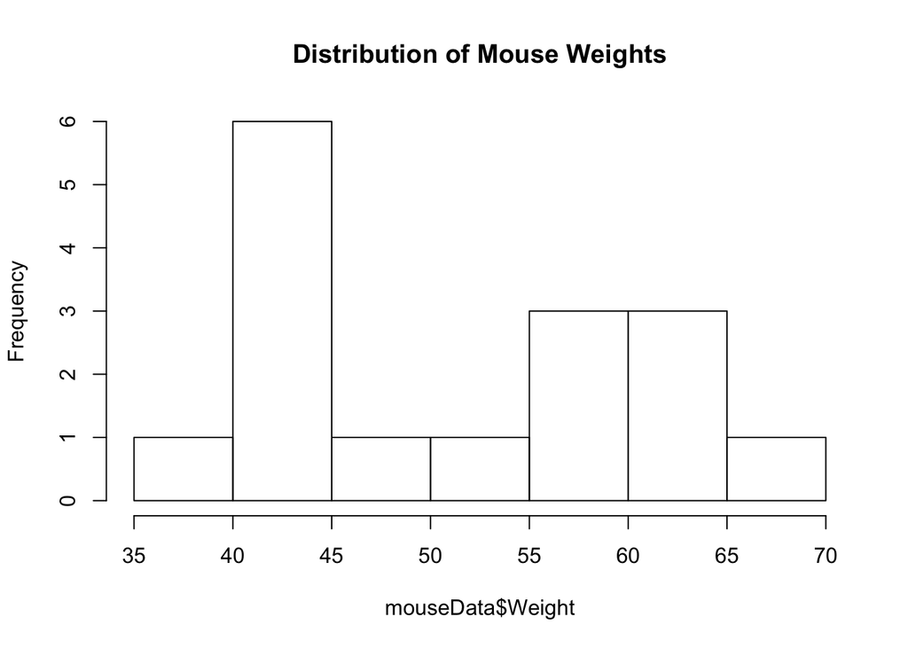

```r
hist(mouseData$Weight, main = "Distribution of Mouse Weights")
```

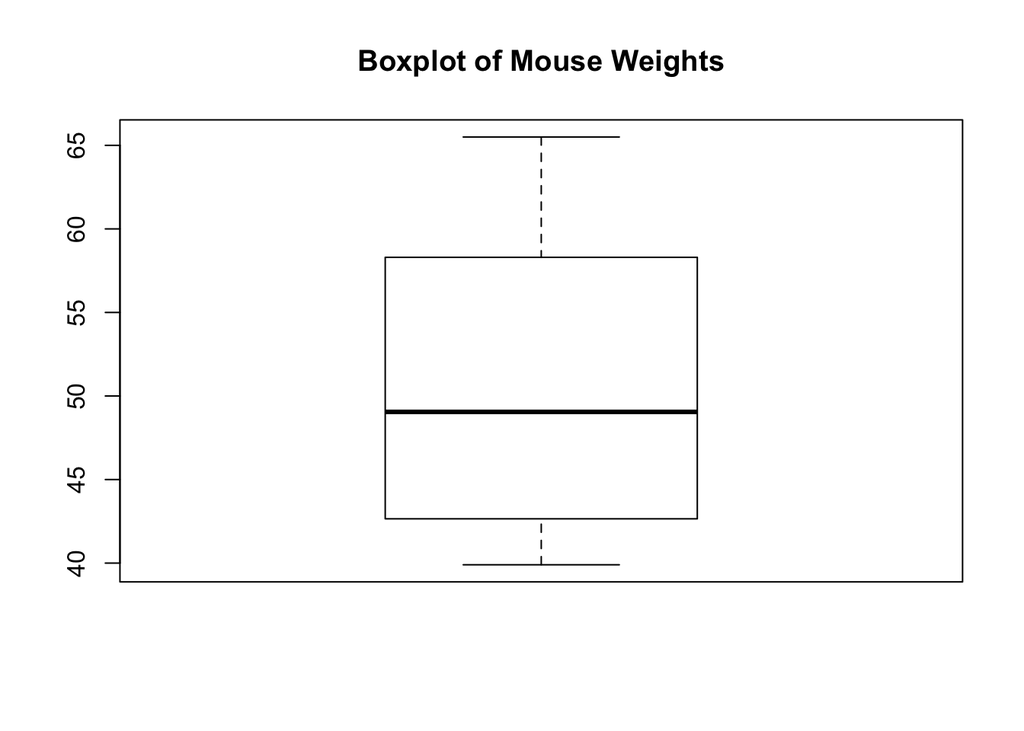

```r
boxplot(mouseData$Weight, main = "Boxplot of Mouse Weights")
```

We can save these graphs to a file by wrapping the plotting command with png() or pdf(). These commands open a pdf or png ‘device’ (basically a blank canvas) that graphics files can be written to.

Note that for pdf(), height and width are specified in inches. pdf() gives the most professional looking results for simple files. When we are done plotting, dev.off() closes the device and writes the file.

```r
pdf(file="mouseData-histogram.pdf", height=5, width=5)
hist(mouseData$Weight, main = "Distribution of Mouse Weights")
dev.off()
```

Note for png(), height and width are specified in pixels.

```r
png("mouseData-boxplot.png", height=500, width=500)
boxplot(mouseData$Weight, main = "Boxplot of Mouse Weights")
dev.off()
```

## Part 3: Saving Data

Saving data to table format is done using the write.table() command. Let’s write mouseData to a csv file by changing our sep argument

```r
write.table(mouseData, file="mouseData2.csv", sep=",")
```

**PROBLEM 3-1**: Examine the output file mouseData2.csv in a text editor. What do you notice about this file? Is the number of columns equal to the number of entries in the header? If not, why do you think this is the case?

```r
##Space here for your answer.
```

```r
write.table(mouseData, file="mouseData2.csv", sep=",", col.names=NA)
```

Note that write.table() by default saves the row names, but does not give them a name in the column header. You can turn this off by setting row.names=FALSE, if row names are not necessary.

```r
write.table(mouseData, file="mouseData2.csv", sep=",", row.names=FALSE)
```

## Part 4: Scripting

We can save a series of R commands to produce a script. Scripts are the basis of workflows and pipelines. They’re simply collections of commands that are put together in a single file.

Let’s run a script - what does it output?

```r
source("testScript.R")
```

**QUESTION 4-1**: There is a mistake in the script. What is it? Use the Error that is returned when running it to figure out what is wrong. Fix it, and run it.

```r
##Space here for your answer.
```

**QUESTION 4-2**: Modify the Script to produce a png file instead of a pdf file. Confirm the script produces the correct output by running it.

```r
##Space here for your answer.
```

## Part 5: Let’s Knit!

In order to knit this report together, we need to confirm that the knitr package is installed in RStudio.

```r
#confirm that running the following returns no errors
library(knitr)
```

If the knitr package is not installed, then you will need to install it.

```r
install.packages("knitr")
library(knitr)
```

Once that’s done, we can knit our file. Try out the following command. What is the knitted file saved as?

```r
knit("module1.Rmd")
```

### Final Problem For Module 1:

Fill out the included “module1-final-problem.R” file to do the following:

1. Set current working directory
2. load in “mouseData.txt”
3. subset the first 10 rows of the file to a new object (such as mouseSubset)
4. save a PDF of the boxplot of the weights to “mouse-subset-boxplot.pdf”
5. save the subset as a csv file called “mouse-subset.csv”

Confirm that your script runs using source() and outputs the correct formats for each file.